# PRACTICAL WORK

Proposed by

**PATRICK VALDURIEZ & CARLYNA BONDIOMBOUY**

IMSP-INRIA

## Install Neo4j on Windows

### Working with Neo4j

Neo4j provides an in-built browse application to work with Neo4j. You can access Neo4j using the URL http://localhost:7474/

```
C:\Program Files\Python37>pip install neo4j

C:\Program Files\Python37>pip install py2neo

C:\Program Files\Python37>pip install neo4j-driver

C:\Users\carlyna.bondiombouy\neo4j-community-3.5.3>

C:\Users\carlyna.bondiombouy\neo4j-community-3.5.3>cd bin

C:\Users\carlyna.bondiombouy\neo4j-community-3.5.3\bin>ls

cypher-shell.bat  neo4j-import.bat  Neo4j-Management.psd1  tools

neo4j-admin.bat   neo4j-import.ps1  neo4j.bat

neo4j-admin.ps1   Neo4j-Management  neo4j.ps1

C:\Users\carlyna.bondiombouy\neo4j-community-3.5.3\bin>neo4j.bat install-service
Neo4j service installed

C:\Users\carlyna.bondiombouy\neo4j-community-3.5.3\bin>net start neo4j

Le service Neo4j Graph Database - neo4j démarre.

Le service Neo4j Graph Database - neo4j a démarré.


C:\Users\carlyna.bondiombouy\neo4j-community-3.5.3\bin>net stop neo4j

Le service Neo4j Graph Database - neo4j s’arrête.

Le service Neo4j Graph Database - neo4j a été arrêté.
```

## Mac Installation (dmg)

1. The installer includes the Java version needed for running Neo4j.
2. Open the dmg file you just downloaded.
3. Drag the Neo4j icon into your Applications folder. Watch the video to see this in action.
4. Open Neo4j from your Applications folder. You might need to acknowledge that you downloaded the application from the Internet.
5. Click on the Start button to start the Neo4j server.
6. Open the provided URL in your local web browser.
7. Change the password for the neo4j account.

## Linux/UNIX Install (tar)

1. Open up your terminal/shell.
2. Extract the contents of the archive, using: tar -xf $<filecode>$. For example,
3. tar -xf neo4j-enterprise-2.3.1-unix.tar.gz the top level directory is referred to as NEO4J_HOME
4. Run Neo4j using $NEO4J_HOME/bin/neo4j console. Instead of ‘neo4j console’, you can use neo4j start to start the server process in the background.
5. Visit http://localhost:7474 in your web browser.
6. Change the password for the neo4j account.

## Exercise

### Create Node with Properties

1. Create nodes

```
CREATE (node:label { key1: value, key2: value, . . . . . . . . .  })
```

1. Verification

To verify the creation of the node, type and execute the following query in the dollar prompt.

```
MATCH (n) RETURN n
```

```
CREATE (Ebohon:Attraction {name:'Chief Priest Osemwengie Ebohon Botanical Garden', location:'Benin City',  status:'functional'})
CREATE (Ogbe:Person {name:'Ogbe Oronsaye ', born:1964})
CREATE (Uyiosa:Person {name:'Uyiosa Idehen', born:1967})
CREATE (Igbinosa:Person {name:'Igbinosa Bello', born:1961})
CREATE (Abeni:Person {name:'Abeni Davies', born:1960})
CREATE (Oriafo:Person {name:'Oriafo Osigbemhe', born:1967})
CREATE (Bello:Person {name:'Bello Ogbeide', born:1965})
CREATE (Adizie:Person {name:'Adizie Solomon', born:1952})
CREATE
  (Ogbe)-[:VISITED]->(Ebohon),
  (Uyiosa)-[:VISITED]->(Ebohon),
  (Igbinosa)-[:VISITED]->(Ebohon),
  (Abeni)-[:VISITED]->(Ebohon),
  (Oriafo)-[:MANAGED]->(Ebohon),
  (Bello)-[:MANAGED]->(Ebohon),
  (Adizie)-[:CONTRIBUTE]->(Ebohon)


CREATE (Abulu:Person {name:" Abulu Cole", born:1978})
CREATE (Abulu)-[:CLEANED {roles:["Abulu"]}]->(Ebohon)


CREATE (Ogiamen:Attraction {name:'Ogiamen Palace', location:'Benin City',  status:'functional'})
CREATE (historical:Place {name:'historical places'})
CREATE (monuments:Place {name:'monuments'})
CREATE (temples:Place {name:'ancient temples'})
CREATE (zoos:Place {name:'zoos'})
CREATE (aquaria:Place {name:'aquaria'})
CREATE (museums:Place {name:'museums and art galleries'})
CREATE (parks:Place {name:'theme parks and carnivals'})
CREATE
  (historical)-[:INCLUDE]->(Ogiamen),
  (monuments)-[:INCLUDE]->(Ogiamen),
  (temples)-[:INCLUDE]->(Ogiamen),
  (zoos)-[:INCLUDE]->(Ogiamen),
  (aquaria)-[:INCLUDE]->(Ogiamen),
  (museums)-[:INCLUDE]->(Ogiamen),
  (parks)-[:INCLUDE]->(Ogiamen)


CREATE (gardens:Place {name:'botanical gardens'})
CREATE (buildings:Place {name:'buildings and structures'})
CREATE (art:Place {name:'public art'})
CREATE
  (historical)-[:INCLUDE]->(Ebohon),
  (monuments)-[:INCLUDE]->(Ebohon),
  (temples)-[:INCLUDE]->(Ebohon),
  (gardens)-[:INCLUDE]->(Ebohon),
  (buildings)-[:INCLUDE]->(Ebohon),
  (art)-[:INCLUDE]->(Ebohon),
  (zoos)-[:INCLUDE]->(Ebohon),
  (aquaria)-[:INCLUDE]->(Ebohon)

RETURN Ebohon,Ogbe,Uyiosa,Igbinosa,Abeni,Oriafo,Bello,Adizie,Abulu,Ogiamen,historical,monuments,temples,zoos,aquaria,museums,parks,gardens,buildings,art
```

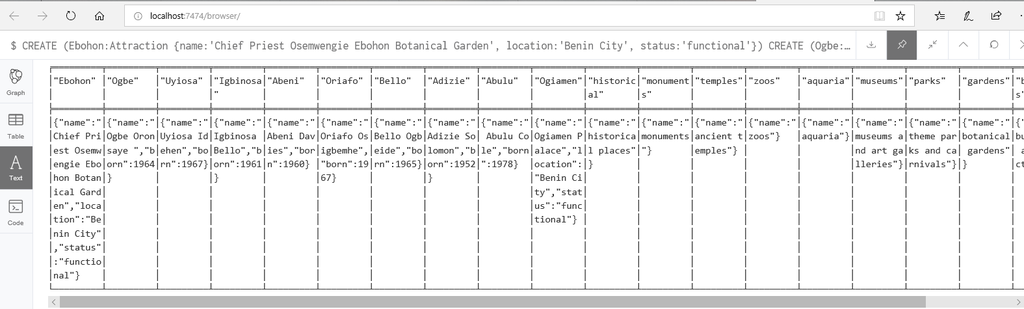

```python
from IPython.display import Image
Image(filename='C:/Users/carlyna.bondiombouy/Desktop/IMSP SPARK/create.png')
```

[figure not shown]

```python
from IPython.display import Image
Image(filename='C:/Users/carlyna.bondiombouy/Desktop/IMSP SPARK/graph.png')
```

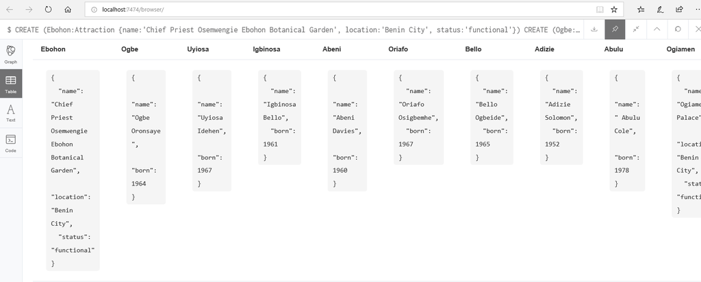

```python
from IPython.display import Image
Image(filename='C:/Users/carlyna.bondiombouy/Desktop/IMSP SPARK/table.png')
```

```
CREATE (Oba:Attraction {name:'Oba Palace and Walls', location:'Benin City', status:'functional'})
CREATE (Edoka:Person {name:'Edoka Adolphuse', born:1970})
CREATE (Adolor:Person {name:'Adolor Aiwerioba', born:1977})
CREATE (Abrose:Person {name:'Ambrose Anegbette', born:1967})
CREATE (Ebelle:Person {name:'Dagbala Ebelle', born:1969})
CREATE (Oriafo:Person {name:'Oriafo Osigbemhe', born:1966})
CREATE (Bello:Person {name:' Edeki Edokpolo ', born:1969})
CREATE (Adizie:Person {name:'Adizie Solomon', born:1976})
CREATE
  (Ogbe)-[:VISITED]->(Oba),
  (Uyiosa)-[:VISITED]->(Oba),
  (Igbinosa)-[:VISITED]->(Oba),
  (Abeni)-[:VISITED]->(Oba),
  (Oba)-[:VISITED]->(Oba),
  (Adolor)-[:VISITED]->(Oba),
  (Abrose)-[:VISITED]->(Oba),
  (Ebelle)-[:VISITED]->(Oba),
  (Oriafo)-[:INVEST]->(Oba),
  (Bello)-[:MANAGED]->(Oba),
  (Adizie)-[:EMPLOY]->(Oba)

CREATE (art:Place {name:'public art'})
CREATE (museums:Place {name:'living history museums'})
CREATE (events:Place {name:'historic trains and cultural events'})
CREATE (ethnic:Place {name:'ethnic enclave communities'})
CREATE (signs:Place {name:'signs'})
CREATE
  (art)-[:INCLUDE]->(Oba),
  (museums)-[:INCLUDE]->(Oba),
  (events)-[:INCLUDE]->(Oba),
  (ethnic)-[:INCLUDE]->(Oba),
  (signs)-[:INCLUDE]->(Oba)

RETURN Oba,Edoka,Adolor,Abrose,Ebelle,Oriafo,Bello,Adizie,art,museums,events,ethnic,signs
```

### Create an index

An index is a data structure that improves the speed of data retrieval operations in a database.

To create an index, use the CREATE INDEX ON statement. Like this:

```
CREATE INDEX ON :Person(Name)
```

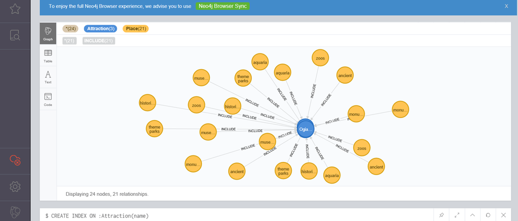

```python
from IPython.display import Image
Image(filename='C:/Users/carlyna.bondiombouy/Desktop/IMSP SPARK/index.png')
```

### Create a constraint and query data

1. Constraints help enforce data integrity.

```
$ CREATE CONSTRAINT ON (Oba:Attraction) ASSERT Oba.Name IS UNIQUE
```

1. The MATCH statement is used to match a given criteria, but it doesn't actually return the data. To return any data from a MATCH statement, we still need to use the RETURN clause.

```
$ MATCH (person:Person)-[:VISITED]->(place:Attraction)
WHERE person.name = "Bello"
RETURN person

$ MATCH (n) RETURN n


$ MATCH (p:Person)
WHERE p.name = "Adolor"
RETURN p
```

### Import data from a csv

```
$ LOAD CSV FROM 'https://www.quackit.com/neo4j/tutorial/genres.csv' AS line
CREATE (:Genre { GenreId: line[0], Name: line[1]})

$ LOAD CSV WITH HEADERS FROM 'https://www.quackit.com/neo4j/tutorial/tracks.csv' AS line
CREATE (:Track { TrackId: line.Id, Name: line.Track, Length: line.Length})

$ USING PERIODIC COMMIT
LOAD CSV WITH HEADERS FROM 'https://www.quackit.com/neo4j/tutorial/tracks.csv' AS line
CREATE (:Track { TrackId: line.Id, Name: line.Track, Length: line.Length})
```

### Drop and delete

1. Drop an index

   ```
   $ DROP INDEX ON :Attraction(name)

   $ :schema
   ```

2. Drop a constraint

   ```
   $ DROP CONSTRAINT ON (Oba:Attraction) ASSERT Oba.Name IS UNIQUE
   ```

3. Delete node

```
$ MATCH (Oba:Attraction {name: "Oba Palace and Walls"}) DELETE Oba
```

1. Relationship

```
$ MATCH ()-[v:VISITED]-()
  DELETE v
```